# Tugas Kelompok MPDW Pertemuan 8

## Forecasting

Peramalan dilakukan untuk 45 periode ke depan.

### Plot Peramalan Pada Model

```r
ramalan<- forecast::forecast(model2, h = 45)
ramalan
```

```
##     Point Forecast       Lo 80       Hi 80       Lo 95       Hi 95
## 251    0.005582961 0.005209589 0.005956333 0.005011937 0.006153984
## 252    0.005629243 0.005136739 0.006121746 0.004876024 0.006382461
## 253    0.005675924 0.005082530 0.006269318 0.004768406 0.006583442
## 254    0.005721145 0.005046871 0.006395418 0.004689933 0.006752356
## 255    0.005764142 0.005024028 0.006504257 0.004632236 0.006896049
## 256    0.005804223 0.005011176 0.006597270 0.004591362 0.007017084
## 257    0.005840912 0.005005966 0.006675858 0.004563972 0.007117852
## 258    0.005873903 0.005006462 0.006741343 0.004547267 0.007200538
## 259    0.005903036 0.005011001 0.006795072 0.004538786 0.007267287
## 260    0.005928280 0.005018157 0.006838404 0.004536367 0.007320194
## 261    0.005949705 0.005026725 0.006872685 0.004538130 0.007361281
## 262    0.005967464 0.005035717 0.006899211 0.004542479 0.007392448
## 263    0.005981774 0.005044348 0.006919200 0.004548105 0.007415443
## 264    0.005992901 0.005052035 0.006933767 0.004553971 0.007431831
```

[output cut: 31 more lines]

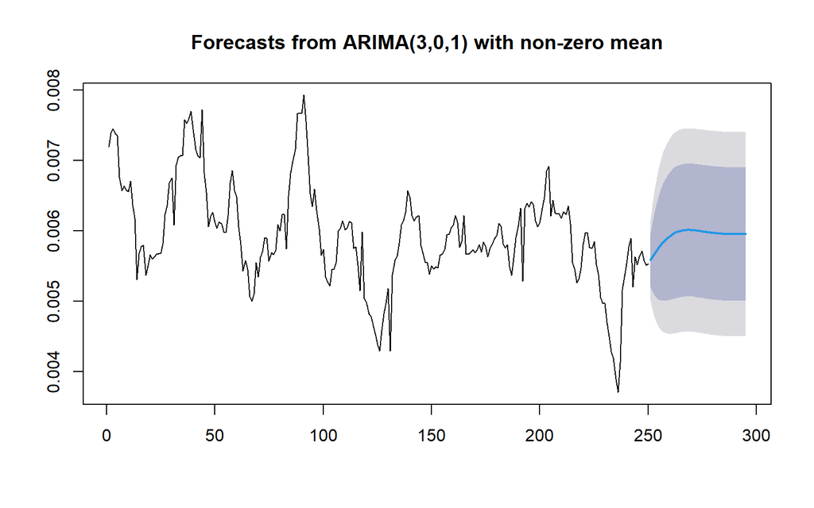

```r
data.ramalan <- ramalan$mean
plot(ramalan)
```

Berdasarkan hasil plot ramalan di atas, dapat dilihat bahwa ramalan ARIMA(3,0,1) cenderung stabil hingga akhir periode. Selanjutnya, dapat dicari nilai akurasi antara hasil ramalan dengan data uji.

### Transformasi Balik

Sebelum melakukan pengecekan akurasi terlebih dahulu dilakukan transformasi balik mengingat data latih sebelumnya ditransformasi dengan lambda -0.5 maka transformasi baliknya adalah inversenya yakni -2.

```r
hasil.trans <- data.ramalan^-2
hasil.trans
```

```
## Time Series:
## Start = 251
## End = 295
## Frequency = 1
##  [1] 32082.70 31557.32 31040.37 30551.61 30097.51 29683.28 29311.54 28983.21
##  [9] 28697.83 28453.95 28249.39 28081.51 27947.31 27843.63 27767.22 27714.84
## [17] 27683.32 27669.59 27670.74 27684.07 27707.05 27737.40 27773.06 27812.21
## [25] 27853.28 27894.90 27935.95 27975.51 28012.87 28047.49 28078.98 28107.13
## [33] 28131.82 28153.06 28170.92 28185.57 28197.22 28206.10 28212.51 28216.71
## [41] 28219.01 28219.69 28219.03 28217.28 28214.69
```

### Akurasi

Selanjutnya, dapat dicari nilai akurasi antara hasil ramalan yang sudah ditransformasi balik dengan data uji sebagai berikut.

```r
perbandingan<-matrix(data=c(head(test.ts, n=45), hasil.trans),
                     nrow = 45, ncol = 2)
colnames(perbandingan)<-c("Aktual","Hasil Forecast")
perbandingan
```

```
##       Aktual Hasil Forecast
##  [1,]  33850       32082.70
##  [2,]  36900       31557.32
##  [3,]  34550       31040.37
##  [4,]  35150       30551.61
##  [5,]  32500       30097.51
##  [6,]  32050       29683.28
##  [7,]  32800       29311.54
##  [8,]  33550       28983.21
##  [9,]  34150       28697.83
## [10,]  35000       28453.95
## [11,]  35000       28249.39
## [12,]  36600       28081.51
## [13,]  39300       27947.31
## [14,]  41200       27843.63
```

[output cut: 31 more lines]

```r
accuracy(ts(hasil.trans), head(test.ts, n=45))
```

```
##                ME     RMSE      MAE      MPE     MAPE      ACF1 Theil's U
## Test set 6045.103 8163.736 7188.166 15.19922 20.01262 0.8126799  2.890894
```

## Simpulan

Dari hasil akurasi tersebut dapat dilihat MAPE dengan nilai 20.01262 yang menggambarkan kebaikan model dalam meramalkan data dengan acuan semakin kecil MAPE semakin baik modelnya. Model yang diperoleh sudah menangani masalah kestasioneran datanya yakni stasioner dalam rataan maupun ragam dengan rataan yang sudah stasioner sedari awal dan ragam yang ditangani dengan transformasi box-cox. Hal ini dapat dimaknai bahwa datalatih dapat meramalkan dengan cukup baik data ujinya sebanyak 45 periode dengan model ARIMA(3,0,1).

Berdasarkan analisis ini juga dapat kita simpulkan bahwa harga bawang merah di kota Surabaya perminggu di 5 tahun terakhir (Januari 2018 - Agustus 2023) dapat kita pergunakan untuk peramalan data selanjutnya dengan pertimbangan dan kebaikan model seperti yang sudah disebutkan sebelumnya (MAPE = 20.01262).

Selanjutnya kami akan lebih menelaah lagi bagaimana menangani permasalahan analisis sisaannya yang belum memenuhi asumsi secara menyeluruh baik dari normalitas maupun homogenitas. Dari sini kami berencana mencobakan metode arch garch kedepannya dengan pertimbangan akan konsultasi terlebih dahulu kepada Asisten.

Sekian untuk analisis kali ini dan terimakasih.